# COVID-19, Informality, and Multidimensional Poverty in Paraguay

# Introduction to the Research Question

In recent years, there has been growing interest in measuring poverty through multidimensional approaches that reflect the lived realities of deprivation beyond income thresholds. The Multidimensional Poverty Index (MPI), developed by the Oxford Poverty and Human Development Initiative (OPHI) and adopted by the UNDP, captures poverty through ten indicators grouped into health, education, and standard of living dimensions (Poverty and Initiative 2021). Paraguay has used MPI in national household surveys since 2016, allowing for a rich analysis of poverty trajectories across different household types, including rural and informal households.

While extensive literature has explored the effectiveness of social protection in reducing income poverty, fewer studies have examined whether emergency cash transfers reduce multidimensional poverty. One of the few exceptions is Esposito and Robson (2023), who show that unconditional cash transfers in Turkey significantly reduced multidimensional poverty among refugee households, especially in access to food, healthcare, and basic services (Esposito and Robson 2023). Similarly, Handa et al. (2020) evaluate a conditional cash transfer program in Kenya and find improvements across several MPI indicators, including school attendance and access to clean water (Handa et al. 2020). These findings suggest that cash transfers—if sufficiently generous and well-targeted—can address more than just income-based needs.

In the case of Paraguay’s Pytyvõ program, the government explicitly targeted informal workers—those without social security coverage or formal employment contracts. As a result, most beneficiaries were likely living in conditions of structural deprivation, yet not classified as income poor in official statistics. According to IMF monitoring data, over 700,000 individuals received Pytyvõ benefits, with evaluations showing short-term effects in reducing income poverty gaps (Fund 2022). However, there is little empirical evidence on whether the program altered broader household-level deprivations in the MPI framework or had differential effects across rural and urban areas.

The broader relevance of this question lies in understanding how emergency responses shape not only income trajectories but also multidimensional outcomes related to human capabilities. By evaluating the Pytyvõ program through an MPI lens, this research contributes to a growing body of literature on social protection in Latin America and offers evidence on how targeting and employment informality intersect with program effectiveness. In countries with limited fiscal space and high informality, these insights are critical for designing resilient and equitable safety nets.

# Theory and Hypotheses

In designing this study, I was motivated by a central question: how does the design of emergency social protection programs influence structural poverty outcomes in contexts of widespread informality? Specifically, I wanted to test whether targeting informal workers during the COVID-19 crisis through Paraguay’s Pytyvõ program helped reduce multidimensional poverty for this group relative to their formal counterparts. This matters not only for understanding Pytyvõ’s short-term effectiveness, but also for informing how governments can better design inclusive relief programs during future crises.

Theoretically, this research is grounded in the growing literature on multidimensional poverty and the limitations of income-based targeting. Traditional income poverty measures often fail to capture deeper and more persistent deprivations related to education, employment formality, housing, and access to services—factors which can shape long-term vulnerability even if income is temporarily above a threshold (Poverty and Initiative 2021; Bastagli et al. 2016). Informal workers, in particular, often fall into this category of “structurally poor,” experiencing multiple deprivations despite sometimes being classified as non-poor in income terms (Handa et al. 2020; Esposito and Robson 2023).

Paraguay’s Pytyvõ program provides a unique empirical opportunity. Unlike most emergency relief programs that rely on income eligibility, Pytyvõ explicitly targeted informality by requiring that recipients lack affiliation with the Instituto de Previsión Social (IPS), Paraguay’s social security system (Color 2020; Nación 2021).

Because Pytyvõ was targeted to informal workers and not based on income, this setting provides a quasi-experimental contrast: formal households were effectively excluded from support during COVID-19, while informal ones were eligible. This institutional feature allows me to examine whether multidimensional poverty outcomes evolved differently for each group during the pandemic period (Handa et al. 2020; Esposito and Robson 2023).

I test two related hypotheses using this contrast between formal and informal households across the pre- and post-pandemic periods. The first examines relative changes in MPI between groups:

> **Hypothesis 1 (H1):** During the COVID-19 period, formal households—who were excluded from Pytyvõ—experienced worse multidimensional poverty outcomes than informal households who received assistance.

This hypothesis posits that the Pytyvõ program causally improved MPI outcomes for informal households, and that the exclusion of formal workers from these transfers may have led to a relative increase in deprivation.

To further explore this dynamic, I introduce a second hypothesis based on an empirical extension:

> **Hypothesis 2 (H2):** Among non-income-poor households, informal households experienced greater improvements in multidimensional poverty during the COVID-19 period than formal households.

This second hypothesis is particularly important because many informal households likely experience structural deprivation despite not being income-poor. If Pytyvõ’s design successfully reached these households, then improvements in their MPI scores—even among the non-income poor—would suggest that targeting informality can be an effective proxy for vulnerability in crisis settings.

In sum, I expect to find a statistically significant interaction between informality and the COVID-19 period, such that informal households benefited more in terms of multidimensional poverty reductions. This expectation is rooted in both the structure of the Pytyvõ program and the broader theoretical insight that income alone is an incomplete metric of poverty. If my hypotheses are confirmed, the results would provide empirical support for using multidimensional indicators and employment formality as targeting criteria in emergency social protection design.

# Research Design

This study evaluates whether Paraguay’s emergency cash transfer program, **Pytyvõ**, inadvertently excluded structurally poor households due to its targeting strategy, which prioritized informal workers during the COVID-19 pandemic. Using nationally representative household survey data from 2016 to 2023, I examine whether formal households — those affiliated with social security and therefore ineligible for Pytyvõ — experienced slower improvements in multidimensional poverty during the COVID period, compared to their informal counterparts, who were eligible.

The primary outcome is the Multidimensional Poverty Index, `M0_26`, which reflects the incidence and intensity of poverty across ten deprivation indicators. This measure is constructed using the Alkire-Foster methodology, though the specific indicators and weights used by Paraguay’s DGEEC are not fully documented. Based on variable naming and structure, I assume consistent use of dimensions related to education, employment, social protection, housing quality, and access to basic services. A binary version of this outcome, `multid_poor_26`, classifies households as poor (`1`) or non-poor (`0`).

The main explanatory variable is formality, proxied by the binary variable `hh_d_no_afil`, which equals `1` if no household member is formally affiliated with the social security system (i.e., informal) and `0` otherwise. The key interaction is with the variable `covid_period`, coded as `1` for 2020–2023 and `0` for 2016–2019, to estimate differences in poverty trends between formal and informal households during the pandemic and recovery period.

### Dataset and Limitations

The dataset is a merged panel of household-year surverys across eight annual waves in Paraguay, with an average of ~10,000 households per year (totaling ~82,000). These surveys are available at the INE (National Institute of Statistics) Paraguay website. While the MPI index is available consistently across years, documentation on the exact construction of the index and sampling protocols is limited. Variable naming conventions suggest consistent methodology, but slight changes in indicator definitions or weighting over time remain possible. To address this, I skimmed throug the datasets an it doesn’t appear to be any inconsistency, such as many NAs or outliers for certain columns.

### Role of Rurality

This analysis is centered on program eligibility. While urban-rural differences are relevant to understanding structural inequality, they are not predictive of Pytyvõ receipt, as I had thought initially. A test of the empirical correlation between informality (`hh_d_no_afil`) and rural residence (`area`) yields only 0.087, indicating that rural households were only marginally more likely to be informal. As a result, I decided to not have rural/urban classifications as a causal proxy for program targeting.

```r
#reading previously merged file with the answers from 2016-2023
fullmerge <- read_csv("/Users/mariaguadalupesolaecheamadeo/MPI_merged_2016_2023.csv",  show_col_types = FALSE)

#measuring correlation between rural and informality
correlation_df <- na.omit(data.frame(
  informal = fullmerge$hh_d_no_afil,              # 1 if informal, 0 if formal
  rural = ifelse(fullmerge$area == 2, 1, 0)       # 1 if rural, 0 if urban
))

cor <- cor(correlation_df$informal, correlation_df$rural, method = "pearson")

# Output result
cat("Correlation between informality and rural area:", round(cor, 3), "\n")
```

```
Correlation between informality and rural area: 0.087
```

Instead, I treat formality as a proxy for program exclusion: households with social security affiliation were ineligible for Pytyvõ, regardless of income or geography. Thus, any widening gap in MPI during the COVID period between formal and informal households may reflect the consequences of exclusion from targeted assistance.

### Summary Statistics

```r
# Summary statistics grouped by year
yearly_summary <- fullmerge %>%
  group_by(year) %>%
  summarise(
    Observations = n(),
    `Mean MPI (M0_26)` = mean(M0_26, na.rm = TRUE),
    `SD of MPI` = sd(M0_26, na.rm = TRUE),
    `Share MPI-Poor` = mean(multid_poor_26, na.rm = TRUE),
    `Share Informal` = mean(hh_d_no_afil, na.rm = TRUE),
    `Share Rural` = mean(area == 2, na.rm = TRUE),
    `Share Income Poor` = mean(pobnopoi, na.rm = TRUE)
  ) %>%
  gt() %>%
  tab_header(title = "Table 1: Summary Statistics by Year") %>%
  fmt_percent(
    columns = c(`Share MPI-Poor`, `Share Informal`, `Share Rural`, `Share Income Poor`),
    decimals = 1
  )

# Display the table
yearly_summary
```

Table 1: Summary Statistics by Year

| year | Observations | Mean MPI (M0_26) | SD of MPI | Share MPI-Poor | Share Informal | Share Rural | Share Income Poor |
| --- | --- | --- | --- | --- | --- | --- | --- |
| 2016 | 10219 | 0.14020461 | 0 | 32.7% | 75.7% | 45.4% | 25.7% |
| 2017 | 17032 | 0.06303682 | 0 | 17.0% | 71.8% | 44.0% | 19.9% |
| 2018 | 4999 | 0.11781019 | 0 | 27.8% | 75.4% | 45.7% | 20.7% |
| 2019 | 5099 | 0.10413604 | 0 | 25.8% | 73.8% | 45.8% | 19.5% |
| 2020 | 4842 | 0.09398603 | 0 | 23.5% | 74.4% | 46.9% | 21.6% |
| 2021 | 4644 | 0.07911301 | 0 | 21.8% | 74.1% | 48.2% | 21.7% |
| 2022 | 17964 | 0.07295788 | 0 | 19.7% | 72.5% | 43.9% | 22.6% |
| 2023 | 17032 | 0.06303682 | 0 | 17.0% | 71.8% | 44.0% | 19.9% |

Multidimensional poverty has shown a general downward trend, with the share of MPI-poor households decreasing from 32.7% in 2016 to 17.0% in 2023. The mean MPI score also declined over the period, from 0.14 to approximately 0.06. These improvements suggest broad gains in living standards, though year-to-year variation—particularly the abrupt drop in 2017—could reflect methodological changes or sampling shifts in the survey rather than real economic change.

Income poverty tracks MPI poverty in broad terms but differs in key periods, illustrating the conceptual distinction between the two. These descriptive patterns justify a dual focus on both income and multidimensional measures when evaluating the impact of COVID-era cash transfers.

### Empirical Extension

To further assess the impact of Pytyvõ on structural poverty, I restrict the sample to non-income-poor households (`pobnopoi = 0`) and re-estimate the model. Since Pytyvõ targeted informal workers regardless of income status, this subgroup allows us to evaluate whether transfers improved MPI outcomes among beneficiaries who were not classified as income poor. If informal households saw better outcomes during the COVID period, it would suggest that targeting based on informality helped reach structurally vulnerable groups often overlooked by income-only metrics. This extension provides a deeper test of whether employment-based eligibility led to meaningful reductions in multidimensional poverty.

# Findings

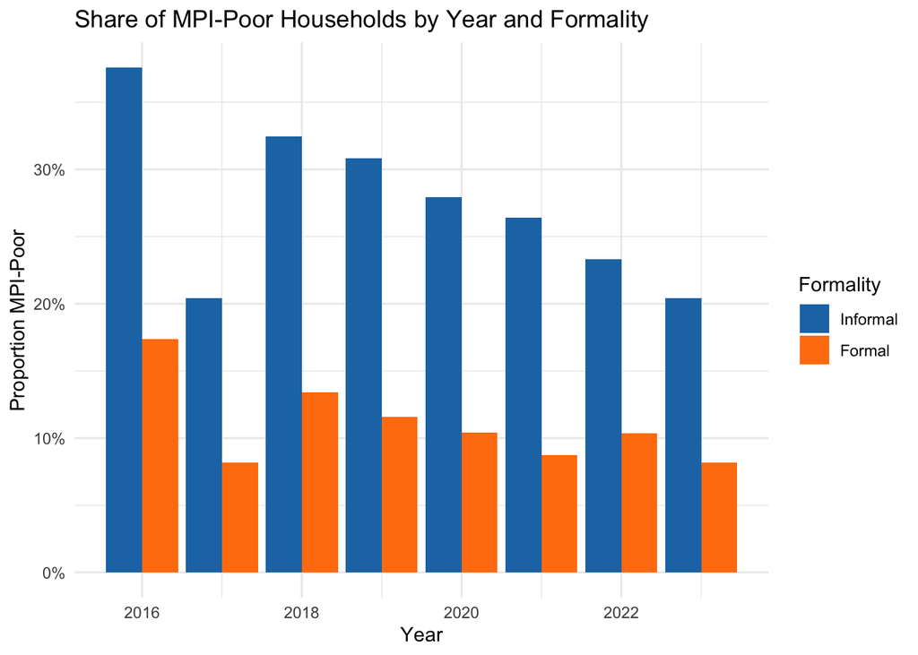

```r
# Share of MPI-poor by year and formality
fullmerge$formal <- 1 - fullmerge$hh_d_no_afil


#filtering out na values
mpi_share <- fullmerge %>%
  filter(!is.na(formal)) %>%  # Remove NA values from 'formal'
  group_by(year, formal) %>%
  summarise(share_mpi_poor = mean(multid_poor_26, na.rm = TRUE)) %>%
  ungroup()


ggplot(mpi_share, aes(x = year, y = share_mpi_poor, fill = as.factor(formal))) +
  geom_bar(stat = "identity", position = "dodge") +
  scale_fill_manual(
    name = "Formality",
    values = c("#1f77b4", "#ff7f0e"),
    labels = c("Informal", "Formal")
  ) +
  labs(
    title = "Share of MPI-Poor Households by Year and Formality",
    x = "Year",
    y = "Proportion MPI-Poor"
  ) +
  scale_y_continuous(labels = scales::percent_format(accuracy = 1)) +
  theme_minimal()
```

*Figure 1.*

[figure not shown]

```r
# MPI vs Income poverty
#creating data set with means of poverty levels for each measure by year
poverty_trends <- fullmerge %>%
  group_by(year) %>%
  summarise(
    mpi_poor = mean(multid_poor_26, na.rm = TRUE),
    income_poor = mean(pobnopoi, na.rm = TRUE)
  ) %>%
  pivot_longer(cols = c(mpi_poor, income_poor),
               names_to = "poverty_type", values_to = "rate")

ggplot(poverty_trends, aes(x = year, y = rate, color = poverty_type, group = poverty_type)) +
  geom_line(size = 1.2) +
  geom_point(size = 2) +
  scale_color_manual(values = c("mpi_poor" = "#1f77b4", "income_poor" = "#2ca02c"),
                     labels = c("MPI Poverty", "Income Poverty"),
                     name = "Poverty Type") +
  labs(title = "Income vs. MPI Poverty Rates Over Time",
       x = "Year", y = "Poverty Rate") +
  scale_y_continuous(labels = scales::percent_format(accuracy = 1)) +
  theme_minimal()
```

*Figure 2.*

```r
# Main regression
fullmerge <- fullmerge %>%
  mutate(covid_period = if_else(year >= 2020, 1, 0))
model_main <- glm(multid_poor_26 ~ covid_period * hh_d_no_afil,
                  family = binomial(link = "logit"),
                  data = fullmerge)

modelsummary(model_main,
             fmt = 3, stars = TRUE,
             title = "Table 2. Main Regression: All Households")
```

Table 2. Main Regression: All Households

|  | (1) |
| --- | --- |
| (Intercept) | -2.030*** |
|  | (0.031) |
| covid_period | -0.242*** |
|  | (0.044) |
| hh_d_no_afil | 1.102*** |
|  | (0.034) |
| covid_period × hh_d_no_afil | -0.035 |
|  | (0.048) |
| Num.Obs. | 81828 |
| AIC | 82314.2 |
| BIC | 82351.4 |
| Log.Lik. | -41153.089 |
| F | 760.274 |
| RMSE | 0.40 |

+ p < 0.1, * p < 0.05, ** p < 0.01, *** p < 0.001

Figure 1 presents the share of MPI-poor households over time, disaggregated by formality. While informal households were consistently poorer, their MPI rates declined more sharply post-2020. This descriptive pattern suggests a potential Pytyvõ effect but must be tested statistically.

# Empirical Extension

```r
model_extension <- glm(multid_poor_26 ~ covid_period * hh_d_no_afil,
                       family = binomial(link = "logit"),
                       data = fullmerge %>% filter(pobnopoi == 0))

modelsummary(model_extension,
             fmt = 3, stars = TRUE,
             title = "Table 3. Empirical Extension: Non-Income-Poor Only")
```

Table 3. Empirical Extension: Non-Income-Poor Only

|  | (1) |
| --- | --- |
| (Intercept) | -2.433*** |
|  | (0.040) |
| covid_period | -0.230*** |
|  | (0.057) |
| hh_d_no_afil | 1.013*** |
|  | (0.044) |
| covid_period × hh_d_no_afil | -0.037 |
|  | (0.062) |
| Num.Obs. | 64275 |
| AIC | 51668.6 |
| BIC | 51704.9 |
| Log.Lik. | -25830.308 |
| F | 390.117 |
| RMSE | 0.35 |

+ p < 0.1, * p < 0.05, ** p < 0.01, *** p < 0.001

To further assess the effectiveness of the Pytyvõ program in reducing structural poverty, I restrict the analysis to households that were not income poor (pobnopoi == 0). This subgroup allows us to test whether Pytyvõ had meaningful impacts on multidimensional poverty (MPI) for informal workers who might have been excluded from traditional income-based poverty classifications but were still eligible for the transfer. Since Pytyvõ targeted employment informality rather than income level, many informal households with incomes just above the poverty line may have still experienced deprivations in education, housing, or access to basic services—dimensions captured by the MPI.

This approach addresses a key policy concern: whether emergency transfers improve structural well-being for recipients outside the usual scope of income-based programs. If Pytyvõ effectively reached these households, I would expect informal workers to experience greater reductions in MPI poverty relative to formal workers during the COVID period, even when excluding the income poor.

However, the results from this restricted regression show no statistically significant interaction effect between COVID and informality (β = -0.037, p > 0.1). While informal workers in this subgroup still faced higher baseline odds of being MPI poor (β = 1.013, p < 0.001), the pandemic period did not lead to differential improvements. This suggests that Pytyvõ may not have been sufficient to reduce broader deprivations, even among those it successfully targeted.

These findings reinforce the need for multidimensional targeting criteria in future transfer programs, as reliance solely on informality may fail to address underlying inequalities not captured by income or employment status alone.

# Discussion and Policy Implications

In short, my findings suggest that while income transfers may buffer short-term income shocks, they are insufficient to reduce multidimensional poverty unless accompanied by deeper reforms in service access, job quality, and protection for the informal sector.

## References

Bastagli, Francesca, Jessica Hagen-Zanker, Luke Harman, Valentina Barca, Georgina Sturge, Tanja Schmidt, and Luca Pellerano. 2016. “Cash Transfers: What Does the Evidence Say? A Rigorous Review of Programme Impact and the Role of Design and Implementation Features.” *ODI Reports*.

Color, ABC. 2020. “Todo Lo Que Necesita Saber Para Acceder Al Subsidio Pytyvõ.” https://www.abc.com.py/nacionales/2020/04/08/todo-lo-que-necesita-saber-para-acceder-al-subsidio-pytyvo/.

Esposito, Lucio, and Elspeth Robson. 2023. “Cash Transfers, Multidimensional Poverty, and Displacement: Evidence from Syrian Refugees in Turkey.” *World Development* 161: 106081.

Fund, International Monetary. 2022. “Paraguay: IMF Staff Concludes 2022 Article IV Mission.” https://www.imf.org/en/News/Articles/2022/05/25/pr22170-paraguay-imf-staff-concludes-2022-article-iv-mission.

Handa, Sudhanshu, Luisa Natali, Gustavo Angeles, and David Seidenfeld. 2020. “Impact of the Kenya CT-OVC Program on Multidimensional Poverty.” *Journal of Development Effectiveness* 12 (1): 1–22.

Ministerio de Hacienda, Paraguay. 2020. “Gobierno Lanza Pytyvõ Para Asistir a Trabajadores Informales.” https://www.hacienda.gov.py/pytyvo.

Nación, La. 2021. “Hacienda Comunicó Que El Programa Pytyvõ 2.0 Finalizó y Benefició a 700.000 Personas.” https://www.lanacion.com.py/negocios/2021/02/28/hacienda-comunico-que-el-programa-pytyvo-20-finalizo-y-beneficio-a-700000-personas/.

Poverty, Oxford, and Human Development Initiative. 2021. “Global Multidimensional Poverty Index 2021.” https://ophi.org.uk/global-mpi-2021/.